# Tolerance of hybrid hosts against infections, TAC Meeting December 2022

Fay Webster

Lubomír Bednář

Emanuel Heitlinger

Abstract

Parasites in hybrid zones can give insight into species barriers, as they are modulating the fitness of hybrid hosts. Recent findings have demonstrated lower infection intensities with parasites in hybrids in the European House Mouse Hybrid zone (HMHZ), indicating higher disease resistance. However, tolerance has not yet been addressed in depth, as it is impractical to measure in wild populations. In an attempt to predict and evaluate the health impact of parasite infections and extrapolate tolerance in the HMHZ, we use a machine learning method. A random forest model was trained on immune parameters measured in experimental lab infections with Eimeria and then applied to data obtained from field sampling. Our predictions revealed that these infections are more detrimental to hybrid male mice. This approach represents an initial step in assessing tolerance in field studies.

# Introduction

## A subsection

A numbered list:

A bullet list:

## Notes

- Extra white space in document will tend to disappear as text is filled in.
- Code blocks tend to generate lots of empty white space when `echo=TRUE` for some reason.

# Literature citations

By default, citations are handled by `natbib` using a numeric citation format. To use name-date citations, sets `namedate: TRUE` in the YAML header.

Here are two sample references:

The bibliography will appear at the end of the document.

Though not normally available in the OUP LaTeX format, [CSL style files](https://www.zotero.org/styles) can also be used with the Rmarkdown adaptation by setting in the YAML header `citation_package: "default"` and defining the `csl` element to be the path towards the style file.

# Equations

An equation without a label for cross-referencing:

$$E=mc^2$$

An inline equation: $y=ax+b$

An equation with a label for cross-referencing:

$$\begin{equation}\label{eq:eq1}
\int^{r_2}_0 F(r,\varphi){\rm d}r\,{\rm d}\varphi = 1
\end{equation}$$

# Inserting R figures

The code below creates a figure. The code is included in the output because `echo=TRUE`.

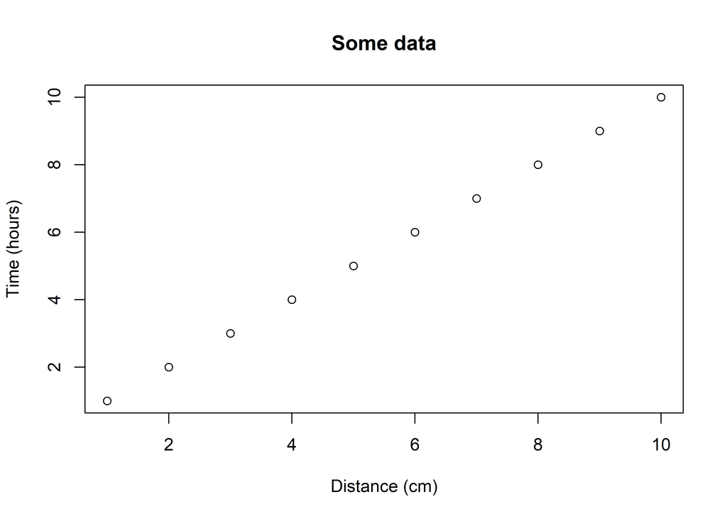

This is the first figure.

```r
plot(1:10,main="Some data",xlab="Distance (cm)",
     ylab="Time (hours)")
```